# Analysis of Environmental Data - Final Project Part 2

Sarah Guitart

### Load data + examine

```r
library(here)
delomys = read.csv(here("data", "delomys.csv"))
head(delomys)
```

|  | observation | genus | binomial | body_mass | body_length | age | sex | longitude | latitude | status |
| --- | --- | --- | --- | --- | --- | --- | --- | --- | --- | --- |
| 1 | 27526 | Delomys | Delomys dorsalis | 50.5 | 259 | adult | female | -48.22950 | -24.20256 | alive |
| 2 | 27528 | Delomys | Delomys dorsalis | 79.0 | 223 | adult | female | -48.22950 | -24.20256 | alive |
| 3 | 27529 | Delomys | Delomys dorsalis | 57.0 | 206 | adult | female | -48.22950 | -24.20256 | alive |
| 4 | 27530 | Delomys | Delomys dorsalis | 71.0 | 229 | adult | male | -48.22950 | -24.20256 | alive |
| 5 | 27533 | Delomys | Delomys dorsalis | 56.0 | 105 | adult | male | -50.39215 | -29.40807 | alive |
| 6 | 27534 | Delomys | Delomys dorsalis | 50.0 | 118 | adult | male | -50.39215 | -29.40807 | dead |

```r
dim(delomys)
```

```
[1] 1585   10
```

```r
str(delomys)
```

```
'data.frame':   1585 obs. of  10 variables:
 $ observation: int  27526 27528 27529 27530 27533 27534 27535 27536 27537 27538 ...
 $ genus      : chr  "Delomys" "Delomys" "Delomys" "Delomys" ...
 $ binomial   : chr  "Delomys dorsalis" "Delomys dorsalis" "Delomys dorsalis" "Delomys dorsalis" ...
 $ body_mass  : num  50.5 79 57 71 56 50 61 87 43 61 ...
 $ body_length: num  259 223 206 229 105 118 123 129 123 125 ...
 $ age        : chr  "adult" "adult" "adult" "adult" ...
 $ sex        : chr  "female" "female" "female" "male" ...
 $ longitude  : num  -48.2 -48.2 -48.2 -48.2 -50.4 ...
 $ latitude   : num  -24.2 -24.2 -24.2 -24.2 -29.4 ...
 $ status     : chr  "alive" "alive" "alive" "alive" ...
```

### Numerical exploration

```r
shapiro.test(delomys$body_length)
```

```
    Shapiro-Wilk normality test

data:  delomys$body_length
W = 0.87609, p-value < 2.2e-16
```

### Graphical exploration

#### Scatterplot

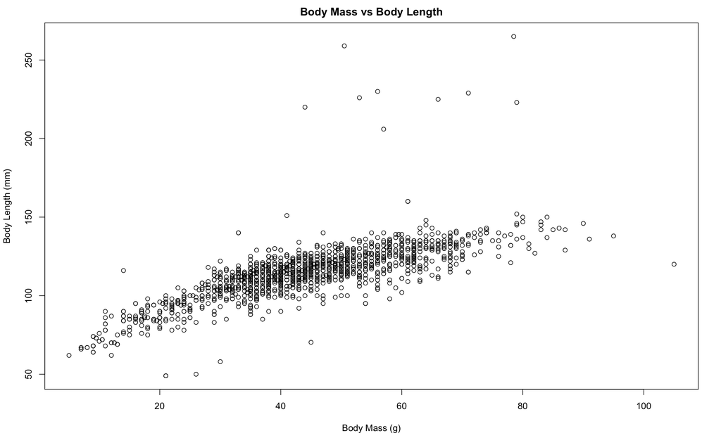

```r
plot(delomys$body_mass, delomys$body_length, main = "Body Mass vs Body Length",
     xlab = "Body Mass (g)", ylab = "Body Length (mm)")
```

#### Histograms

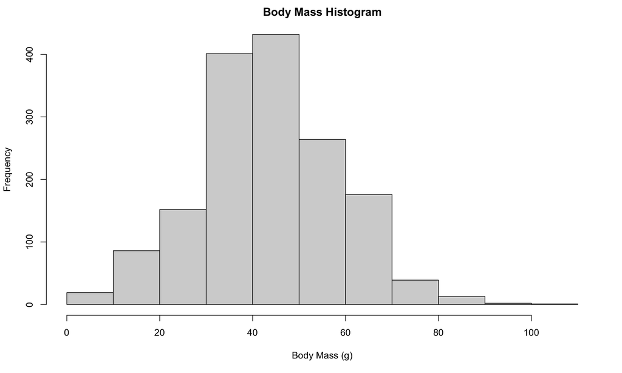

```r
hist(delomys$body_mass, xlab = "Body Mass (g)", main = "Body Mass Histogram")
```

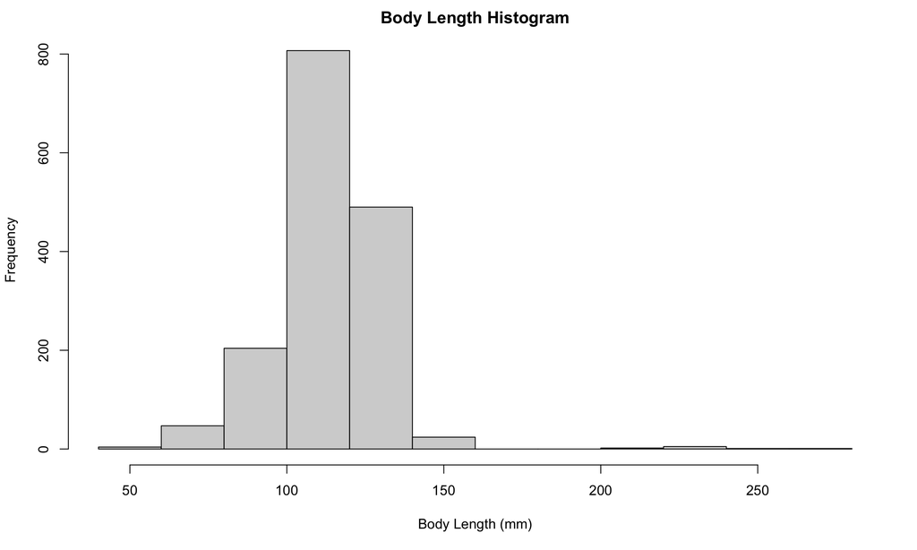

```r
hist(delomys$body_length, xlab = "Body Length (mm)", main = "Body Length Histogram")
```

#### Boxplots

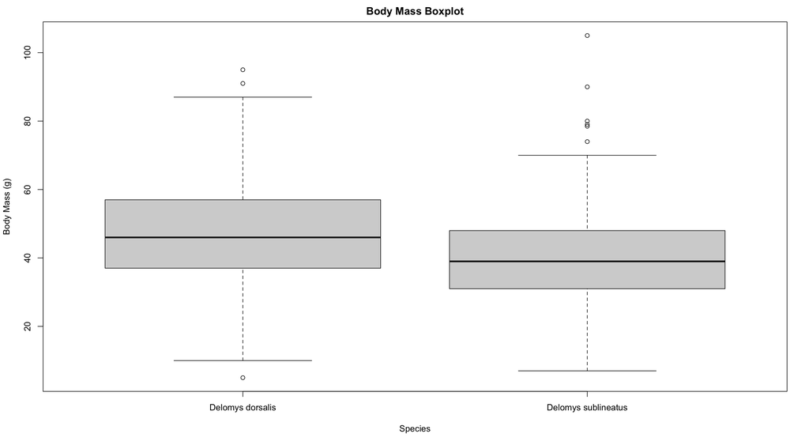

```r
boxplot(body_mass ~ binomial, data = delomys, main = "Body Mass Boxplot",
        xlab = "Species", ylab = "Body Mass (g)")
```

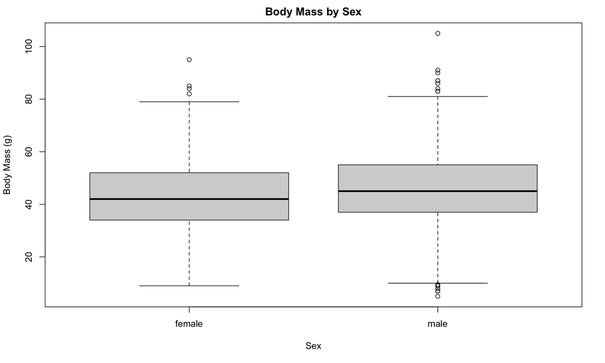

```r
boxplot(body_mass ~ sex, data = delomys, main = "Body Mass by Sex",
        xlab = "Sex", ylab = "Body Mass (g)")
```

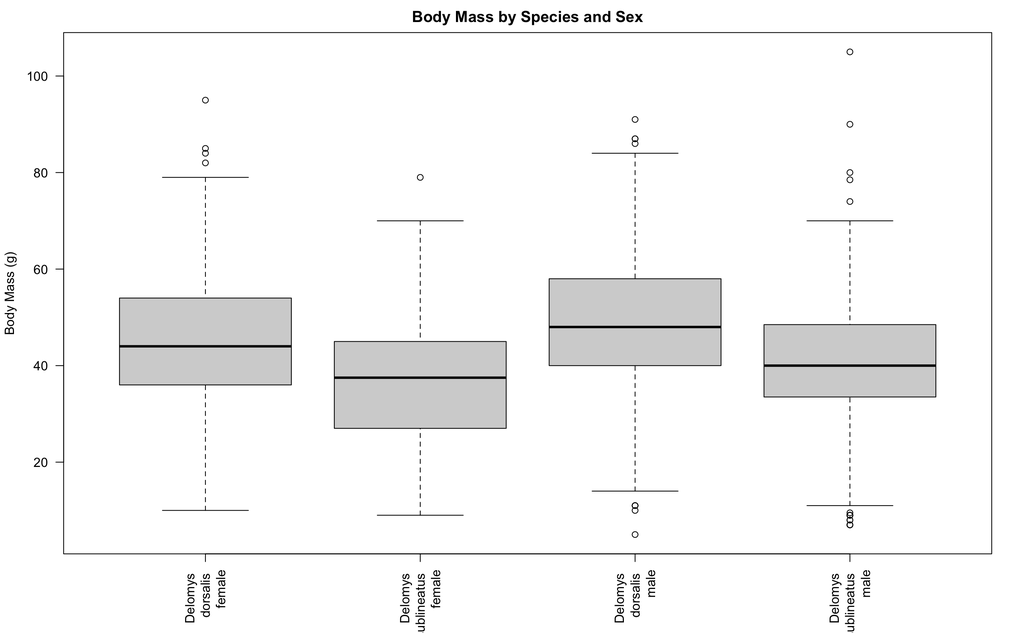

```r
boxplot(body_mass ~ binomial * sex, data = delomys,
        main = "Body Mass by Species and Sex",
        xlab = "", names = c("Delomys \n dorsalis \n female",
                             "Delomys \n sublineatus \n female",
                             "Delomys \n dorsalis \n male",
                             "Delomys \n sublineatus \n male"),
        ylab = "Body Mass (g)", las = 2)
```

### Q1

*Qualitatively describe the relationship between body mass and length. Does the relationship seem linear, curved, nonexistent?*

A: Looking at the scatterplot of body mass and length, the relationship between body mass and length looks linear and monotonic.

### Q2

*Qualitatively describe the shapes of the histograms. Do the data appear normally-distributed? Explain why or why not. Explain why we care (or not) whether the data are normally distributed.*

### Q3

*Using both the histograms and normality tests, do you think the (unconditioned) body masses and body length are normally-distributed? Make sure you contrast your visual assessment of normality to the results of the numerical normality tests.*

### Q4

*Examine the three conditional boxplots. Describe any graphical evidence you see for body mass differences based on species and/or sex.*

A: After examining the three conditional boxplots, I think there is a good amount of graphical evidence for body mass differences based on species and sex.

### Model building

```r
fit1 = lm(body_length ~ body_mass, data = delomys)
fit2 = lm(body_mass ~ sex, data = delomys)
fit3 = lm(body_mass ~ binomial, data = delomys)
fit4 = lm(body_mass ~ sex + binomial, data = delomys)
fit5 = lm(body_mass ~ sex * binomial, data = delomys)
```

```r
anova(fit2)
```

```
Analysis of Variance Table

Response: body_mass
            Df Sum Sq Mean Sq F value    Pr(>F)
sex          1   3062 3061.68  13.943 0.0001951 ***
Residuals 1578 346507  219.59
---
Signif. codes:  0 ‘***’ 0.001 ‘**’ 0.01 ‘*’ 0.05 ‘.’ 0.1 ‘ ’ 1
```

```r
anova(fit3)
```

```
Analysis of Variance Table

Response: body_mass
            Df Sum Sq Mean Sq F value    Pr(>F)
binomial     1  21290 21289.7  102.08 < 2.2e-16 ***
Residuals 1583 330164   208.6
---
Signif. codes:  0 ‘***’ 0.001 ‘**’ 0.01 ‘*’ 0.05 ‘.’ 0.1 ‘ ’ 1
```

```r
anova(fit4)
```

```
Analysis of Variance Table

Response: body_mass
            Df Sum Sq Mean Sq F value    Pr(>F)
sex          1   3062  3061.7  14.958 0.0001144 ***
binomial     1  23727 23727.1 115.923 < 2.2e-16 ***
Residuals 1577 322780   204.7
---
Signif. codes:  0 ‘***’ 0.001 ‘**’ 0.01 ‘*’ 0.05 ‘.’ 0.1 ‘ ’ 1
```

```r
anova(fit5)
```

```
Analysis of Variance Table

Response: body_mass
               Df Sum Sq Mean Sq  F value    Pr(>F)
sex             1   3062  3061.7  14.9489  0.000115 ***
binomial        1  23727 23727.1 115.8500 < 2.2e-16 ***
sex:binomial    1      1     0.8   0.0039  0.950442
Residuals    1576 322779   204.8
---
Signif. codes:  0 ‘***’ 0.001 ‘**’ 0.01 ‘*’ 0.05 ‘.’ 0.1 ‘ ’ 1
```

### Model logistics

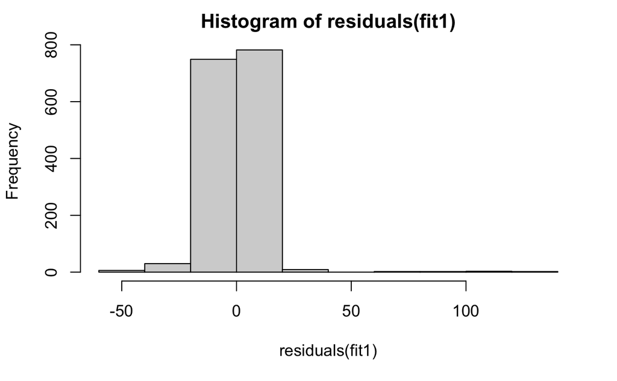

```r
hist1 = hist(residuals(fit1))
```

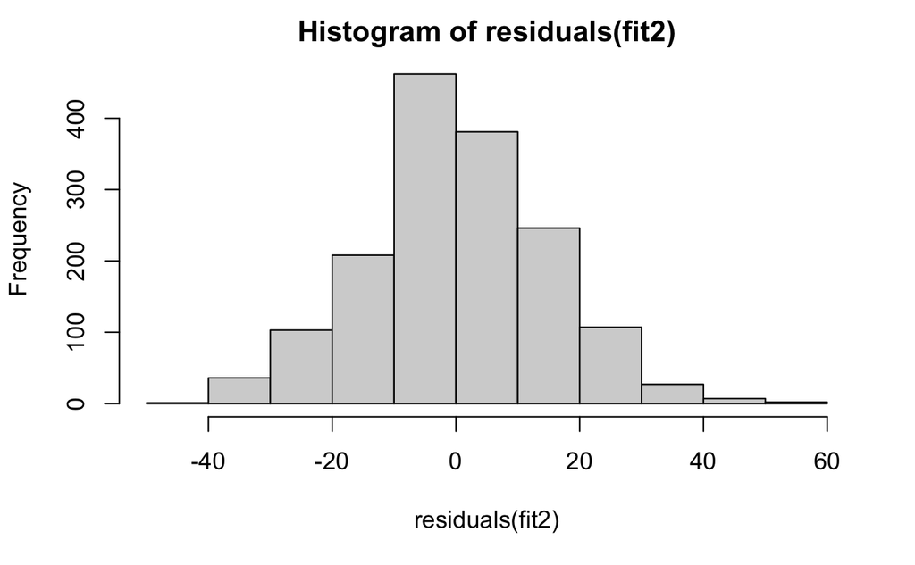

```r
hist2 = hist(residuals(fit2))
```

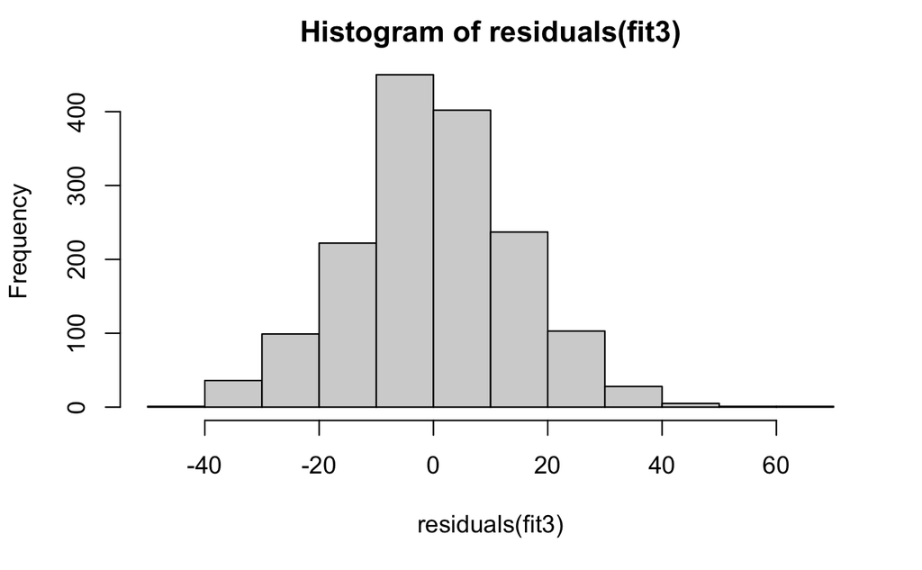

```r
hist3 = hist(residuals(fit3))
```

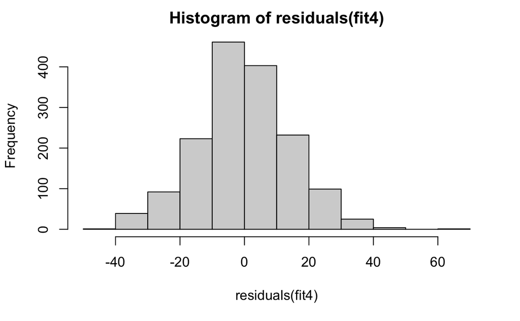

```r
hist4 = hist(residuals(fit4))
```

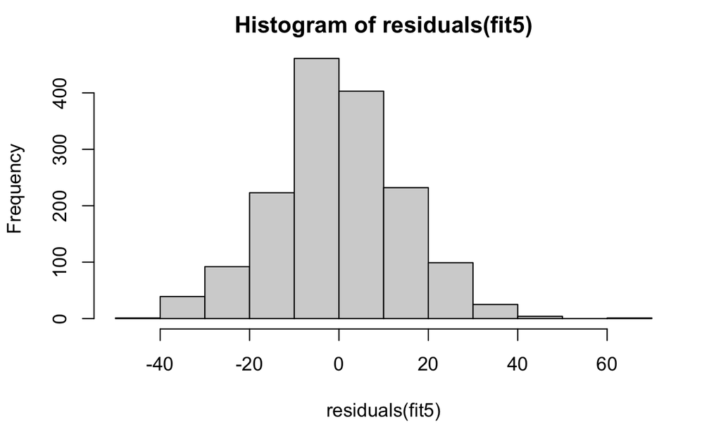

```r
hist5 = hist(residuals(fit5))
```

```r
shapiro.test(residuals(fit1))
```

```
    Shapiro-Wilk normality test

data:  residuals(fit1)
W = 0.73462, p-value < 2.2e-16
```

```r
shapiro.test(residuals(fit2))
```

```
    Shapiro-Wilk normality test

data:  residuals(fit2)
W = 0.99563, p-value = 0.0001541
```

```r
shapiro.test(residuals(fit3))
```

```
    Shapiro-Wilk normality test

data:  residuals(fit3)
W = 0.99535, p-value = 8.103e-05
```

```r
shapiro.test(residuals(fit4))
```

```
    Shapiro-Wilk normality test

data:  residuals(fit4)
W = 0.99525, p-value = 6.805e-05
```

```r
shapiro.test(residuals(fit5))
```

```
    Shapiro-Wilk normality test

data:  residuals(fit5)
W = 0.99526, p-value = 6.816e-05
```

### Q5

*What do you conclude about residual normality based on the numerical and graphical diagnostics?*

A:

### Q6

*Are violations of the normality assumption equally severe for all the models?*

A:

### Model interpretation

```r
knitr::kable(coef(summary(fit1)))
```

|  | Estimate | Std. Error | t value | Pr(>\|t\|) |
| --- | --- | --- | --- | --- |
| (Intercept) | 76.1246565 | 0.9158120 | 83.12258 | 0 |
| body_mass | 0.8754988 | 0.0196905 | 44.46298 | 0 |

```r
knitr::kable(anova(fit2))
```

|  | Df | Sum Sq | Mean Sq | F value | Pr(>F) |
| --- | --- | --- | --- | --- | --- |
| sex | 1 | 3061.678 | 3061.6779 | 13.94294 | 0.0001951 |
| Residuals | 1578 | 346507.131 | 219.5863 | NA | NA |

```r
knitr::kable(anova(fit3))
```

|  | Df | Sum Sq | Mean Sq | F value | Pr(>F) |
| --- | --- | --- | --- | --- | --- |
| binomial | 1 | 21289.68 | 21289.6805 | 102.0751 | 0 |
| Residuals | 1583 | 330164.45 | 208.5688 | NA | NA |

```r
knitr::kable(anova(fit4))
```

|  | Df | Sum Sq | Mean Sq | F value | Pr(>F) |
| --- | --- | --- | --- | --- | --- |
| sex | 1 | 3061.678 | 3061.6779 | 14.95838 | 0.0001144 |
| binomial | 1 | 23727.134 | 23727.1342 | 115.92320 | 0.0000000 |
| Residuals | 1577 | 322779.997 | 204.6798 | NA | NA |

```r
knitr::kable(anova(fit5))
```

|  | Df | Sum Sq | Mean Sq | F value | Pr(>F) |
| --- | --- | --- | --- | --- | --- |
| sex | 1 | 3.061678e+03 | 3.061678e+03 | 14.948932 | 0.0001150 |
| binomial | 1 | 2.372713e+04 | 2.372713e+04 | 115.849977 | 0.0000000 |
| sex:binomial | 1 | 7.913846e-01 | 7.913846e-01 | 0.003864 | 0.9504424 |
| Residuals | 1576 | 3.227792e+05 | 2.048091e+02 | NA | NA |

### Q7

*What is the magnitude of the mass/length relationship?*

A:

### Q8

*What is the expected body length of an animal that weighs 100g?*

A:

### Q9

*What is the expected body length of an animal that weighs 0g?*

A:

### Q10

*What is the base level for sex?*

A:

### Q11

*What is the base level for binomial?*

A:

### Q12

*Which sex is heavier? How do you know?*

A:

### Q13

*Which species is heavier? How do you know?*

A:

### Q14

*Are sex and species significant predictors for body mass?*

A:

### Q15

*Is there a significant interaction?*

A:

### Q16

*Examine the p-values for the main effects (sex and species) in all four of the ANOVA tables. Does the significance level of either main effect change very much among the different models?*

A:

### Model comparison: body mass

```r
AIC(fit2)
```

```
[1] 13006.8
```

```r
AIC(fit3)
```

```
[1] 12966.36
```

```r
AIC(fit4)
```

```
[1] 12896.73
```

```r
AIC(fit5)
```

```
[1] 12898.72
```

### Q17

*Which two models have the lowest AIC?*

A:

### Q18

*Which of the two models with lowest AIC scores would you select? Explain your decision based on model fit and the complexity/understanding tradeoff.*

A: